# Lab1

Samuel Kelly

2021-01-27

# Tasks

## Task 1

Find the working directory

```r
getwd()
```

```
## [1] "C:/Users/semyu/Desktop/Class Work/MATH4753-Applied Statistical Methods/LABS/Lab 1"
```

## Task 2

Read in the DDT data.

```r
ddt <- read.csv("DDT.csv")
head(ddt)
```

```
##   RIVER MILE  SPECIES LENGTH WEIGHT DDT
## 1   FCM    5 CCATFISH   42.5    732  10
## 2   FCM    5 CCATFISH   44.0    795  16
## 3   FCM    5 CCATFISH   41.5    547  23
## 4   FCM    5 CCATFISH   39.0    465  21
## 5   FCM    5 CCATFISH   50.5   1252  50
## 6   FCM    5 CCATFISH   52.0   1255 150
```

## Task 3

1. The qualitative variables are RIVER and SPECIES
2. The quantitative variables are MILE, DDT, LENGTH, and WEIGHT
3. CCATFISH, SMBUFFALO, and LMBASS. There are three different species in the data set.

```r
with(ddt, table(SPECIES))
```

```
## SPECIES
##  CCATFISH    LMBASS SMBUFFALO
##        96        12        36
```

```r
b800 <- with(ddt, ddt[WEIGHT>800 & SPECIES=="LMBASS",])
b800
```

```
##     RIVER MILE SPECIES LENGTH WEIGHT DDT
## 141   TRM  345  LMBASS     30    856 2.2
## 144   TRM  345  LMBASS     36   1433 1.9
```

```r
scm4 <- with(ddt, ddt[RIVER=="SCM" & DDT>4.0,])
scm4
```

```
##    RIVER MILE  SPECIES LENGTH WEIGHT DDT
## 16   SCM    1 CCATFISH     45    984 9.1
## 17   SCM    1 CCATFISH     43    965 7.8
## 18   SCM    1 CCATFISH     45   1084 4.1
```

## Task 4

1. Make a table of the rivers.

```r
riv=with(ddt, table(RIVER))
riv
```

```
## RIVER
## FCM LCM SCM TRM
##   6   6   6 126
```

2. Make a color coded barplot of the rivers.

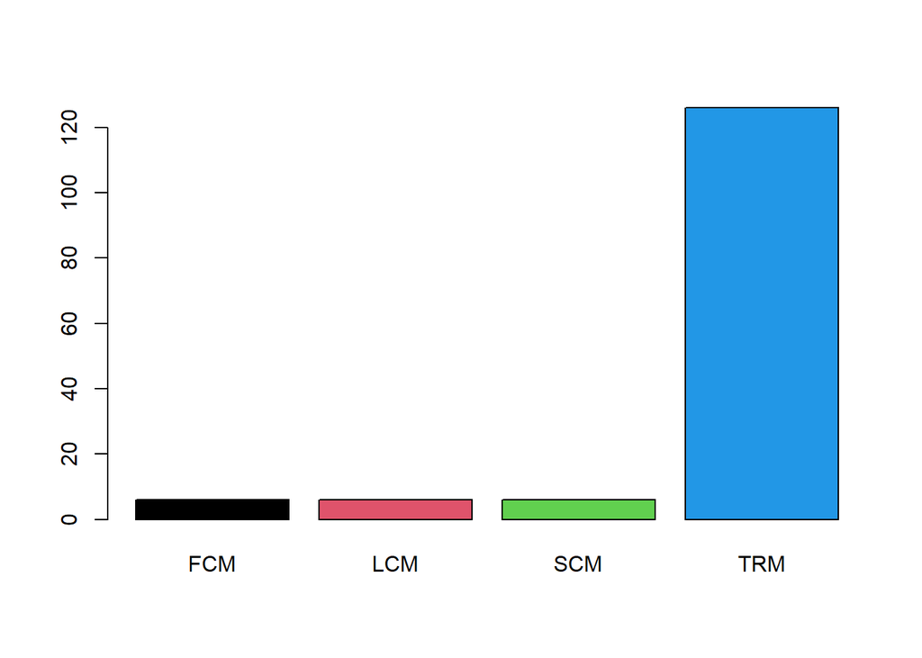

```r
barplot(riv, col = 1:4)
```

3. Make a table of the rivers crossed with the species of fish.

```r
rivsp=with(ddt, table(RIVER,SPECIES))
rivsp
```

```
##      SPECIES
## RIVER CCATFISH LMBASS SMBUFFALO
##   FCM        6      0         0
##   LCM        6      0         0
##   SCM        6      0         0
##   TRM       78     12        36
```

4. Make a barplot of the rivers crossed with the species of fish.

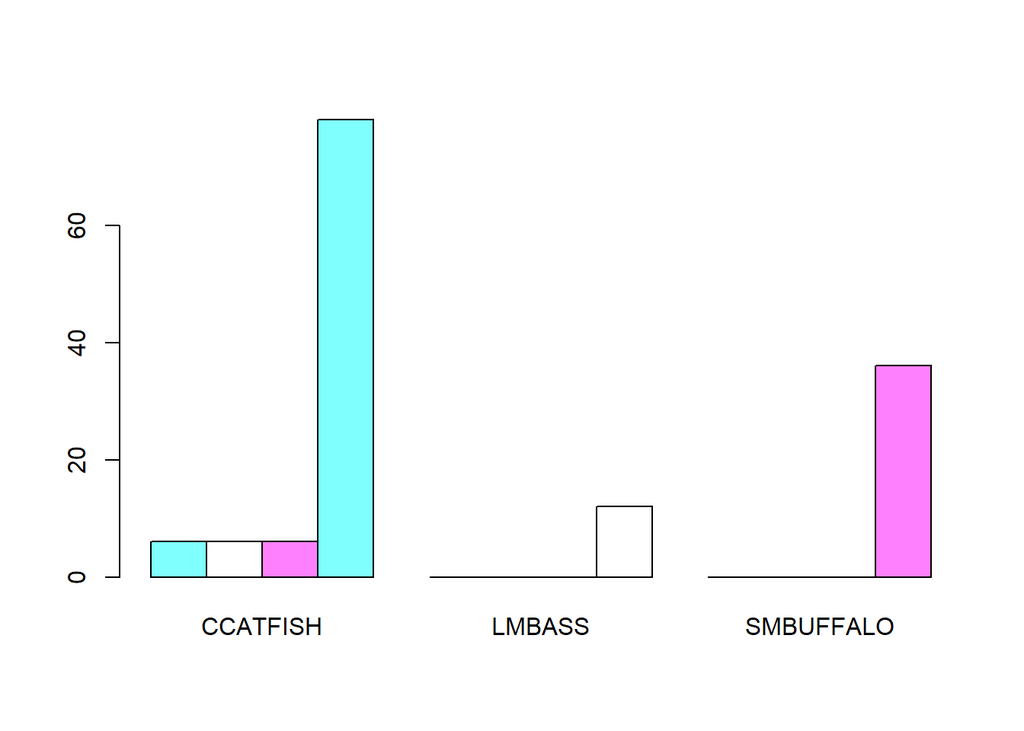

```r
barplot(rivsp,beside = T, col = cm.colors(3))
```

## Task 5

1. Make a pie chart of Fish SPECIES

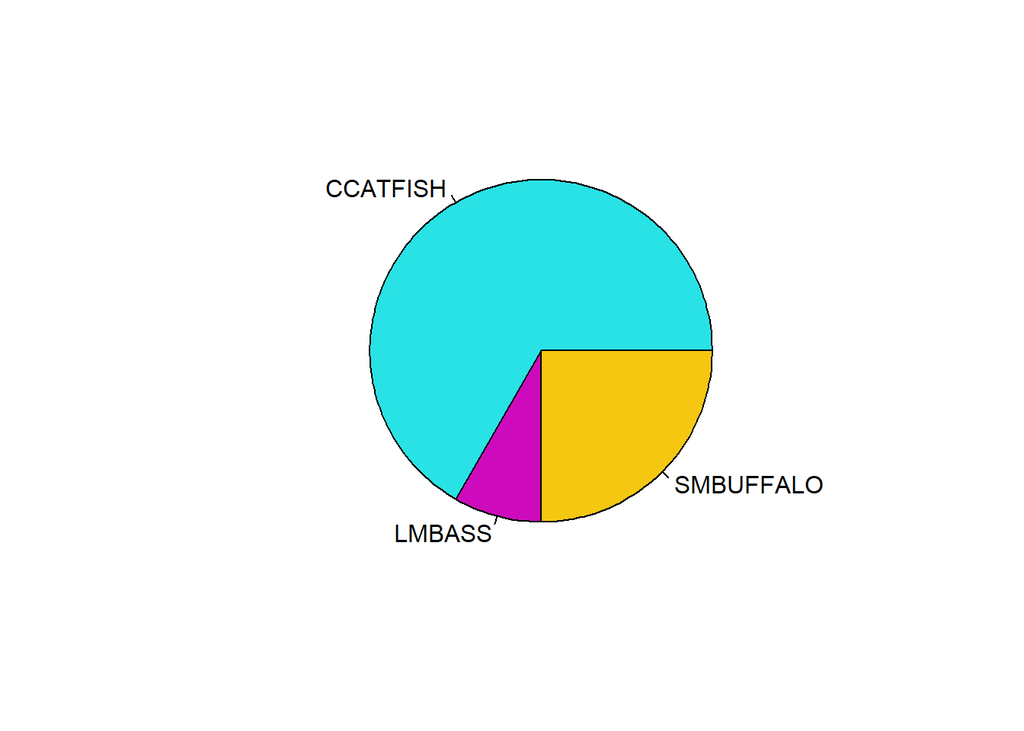

```r
sp=with(ddt, table(SPECIES))
pie(sp, col = 5:7)
```

2. Make a pie chart of RIVERS

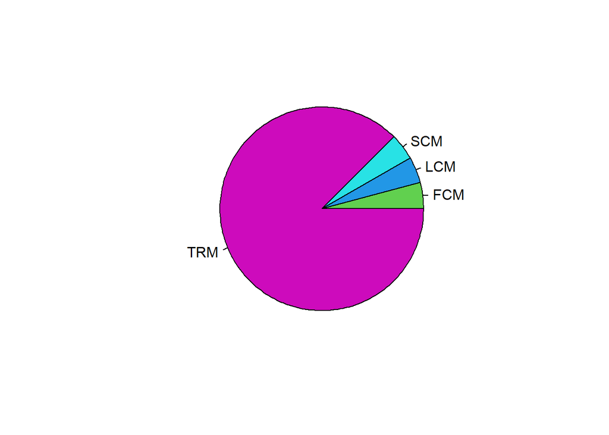

```r
pie(riv, col=3:7)
```

## Task 6

1. Make a boxplot of the variable DDT
2. Make a boxplot of the variable WEIGHT
3. Make a boxplot of the variable LENGTH

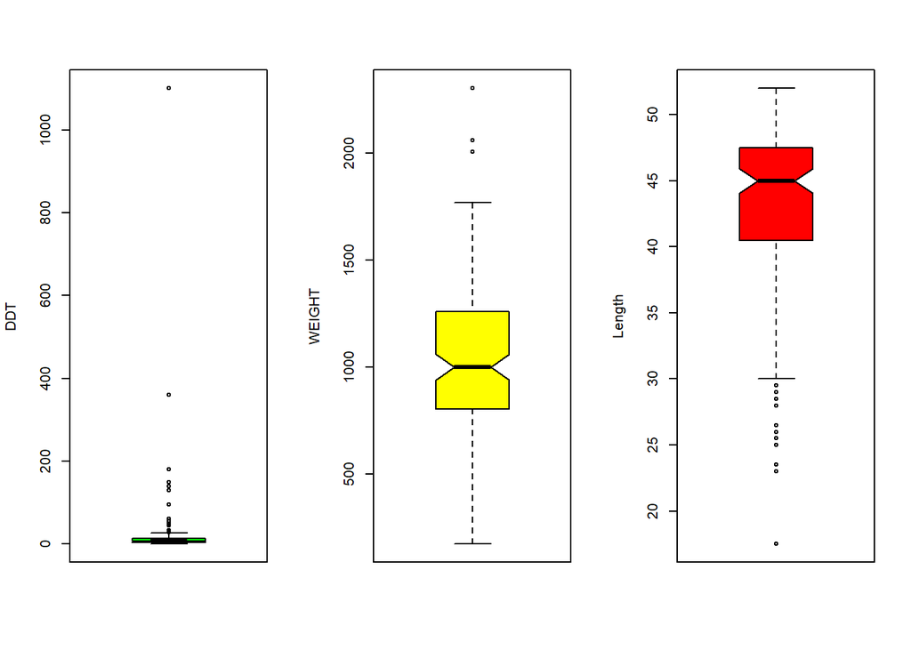

```r
layout(matrix(c(1,2,3), nrow = 1, ncol = 3))
with(ddt, boxplot(DDT, ylab = "DDT",col = "Green",notch=T))
with(ddt, boxplot(WEIGHT, ylab="WEIGHT",col="Yellow",notch=T))
with(ddt, boxplot(LENGTH, ylab="Length",col="Red",notch=T))
```

## Task 7

1. Make a coplot of LENGTH Vs WEIGHT given RIVER

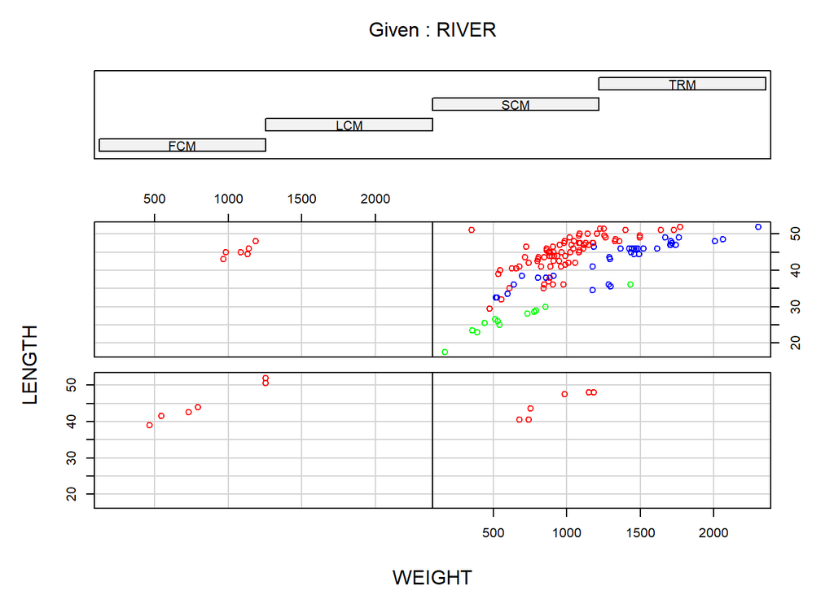

```r
fishcol = with(ddt,ifelse(SPECIES=="CCATFISH","Red",
                          ifelse(SPECIES=="SMBUFFALO","Blue","Green")))
coplot(LENGTH~WEIGHT|RIVER, col = fishcol, data = ddt)
```

2. Make a coplot of DDT Vs WEIGHT given SPECIES

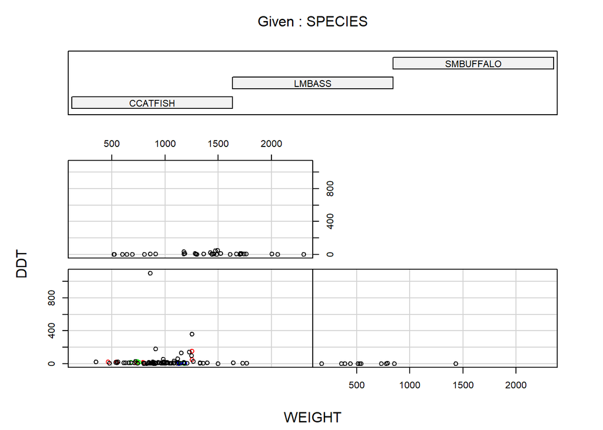

```r
rivcol=with(ddt, ifelse(RIVER=="FCM","Red",
                        ifelse(RIVER=="LCM","Green",
                               ifelse(RIVER=="SCM","Blue","Black"))))
coplot(DDT~WEIGHT|SPECIES, col = rivcol, data=ddt)
```

## Task 8

1. Use ggplot and make the following boxplots (be sure to put your name on the title using ggtitle())

```r
library(dplyr)
```

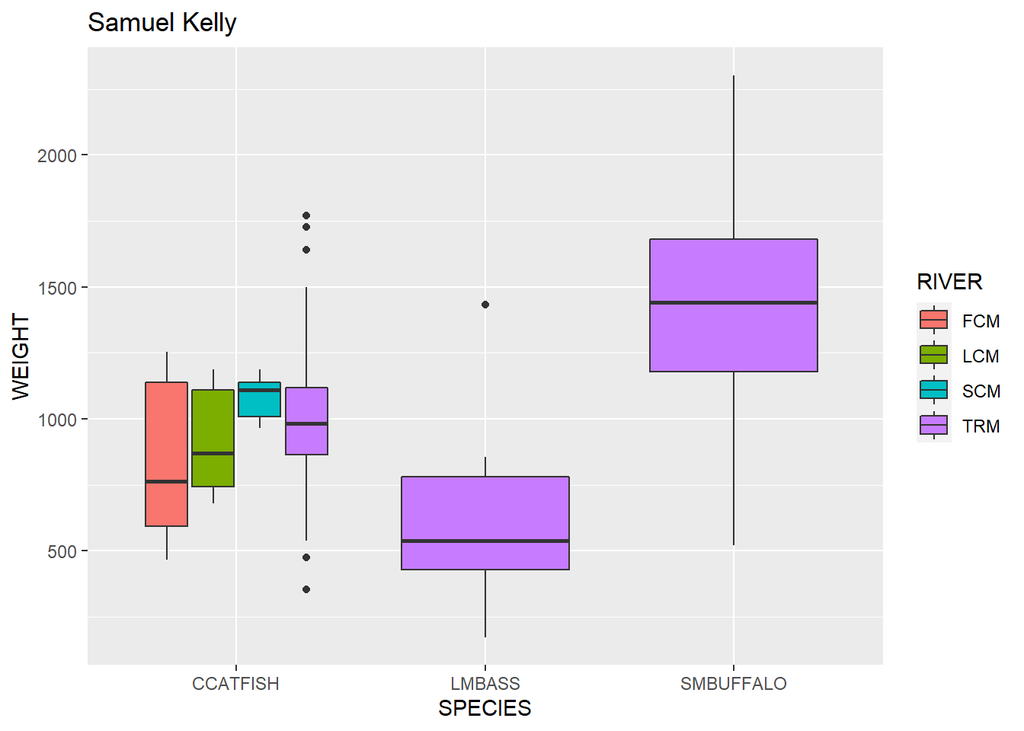

```r
library(ggplot2)
ddt %>% ggplot(aes(x=SPECIES,y=WEIGHT,fill=RIVER)) + geom_boxplot() + ggtitle("Samuel Kelly")
```

2. Use ggplot and make the following violin plots (name on the title)

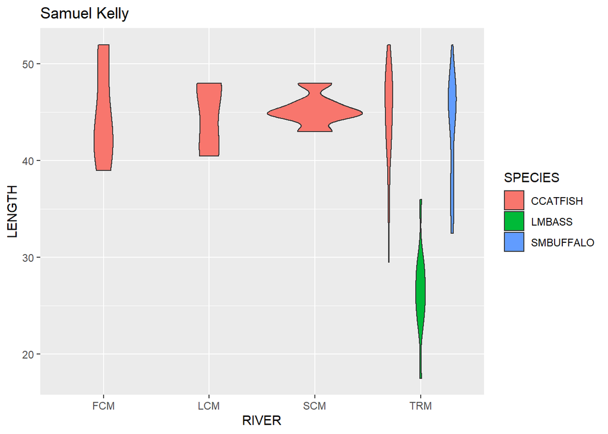

```r
ddt %>% ggplot(aes(x=RIVER,y=LENGTH,fill=SPECIES)) + geom_violin() + ggtitle("Samuel Kelly")
```

3. Use ggplot and make the following scatter plots (name on the title)

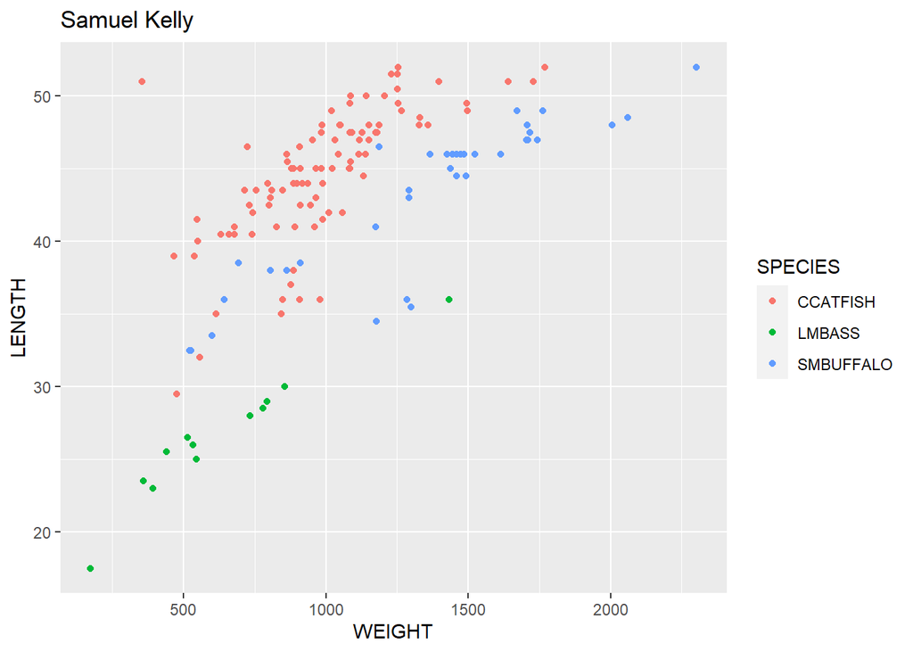

```r
ddt %>% ggplot(aes(x=WEIGHT,y=LENGTH,fill=SPECIES,color=SPECIES)) + geom_point() + ggtitle("Samuel Kelly")
```

## CLICKER QUESTIONS!

1. The average length of the fish is 42.8125.

```r
mean(ddt$LENGTH)
```

```
## [1] 42.8125
```

2. The standard deviation of the fish’s weight is 376.5461.

```r
sd(ddt$WEIGHT)
```

```
## [1] 376.5461
```

3. No, the length and width are on the opposite axis.

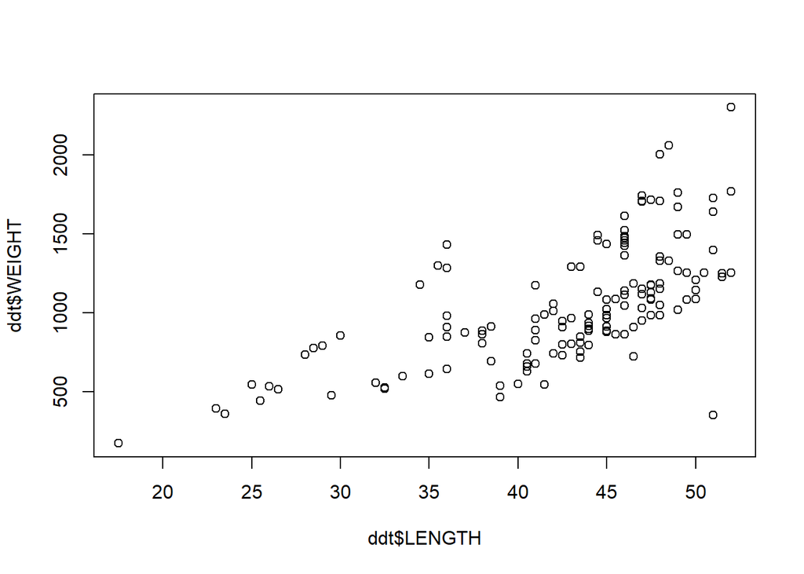

```r
plot(ddt$LENGTH, ddt$WEIGHT)
```

4. It equals 1.00.

```r
v=1:20
v/20
```

```
##  [1] 0.05 0.10 0.15 0.20 0.25 0.30 0.35 0.40 0.45 0.50 0.55 0.60 0.65 0.70 0.75
## [16] 0.80 0.85 0.90 0.95 1.00
```

$$R^2=\frac{MSS}{TSS}$$